# Final Project

Elysa, Kate and Pan

2016年10月28日

## Metropolis-Hastings

Beta(6,4) is the distribution we need to sample from. And the proposal function given is
$$\phi_{prop}|\phi_{old}～Beta(c*\phi_{old},c*(1 - \phi_{old}))$$
, which should be used in acceptance ratio. We also need to consider the fact that the distribution we are sampling from is not sysmetric.

## c=1

Our code for the part with C=1 is shown as the following.

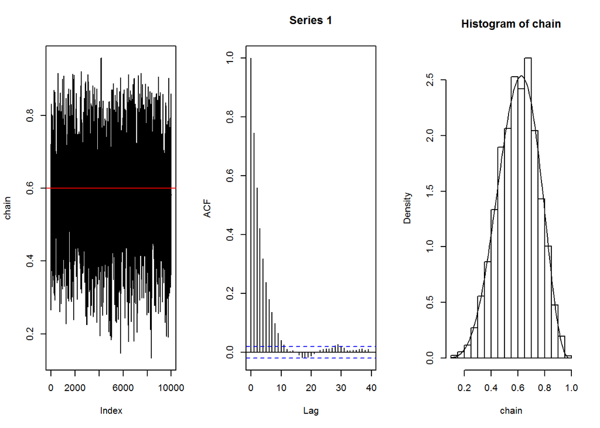

```r
set.seed(1)
#Defination of proposal function
proposalfunction <- function(c, phi_old){
  rbeta(1, c*phi_old,c*(1-phi_old))
}
#The constant in proposal function
c<-1
# MC algorithm
run_metropolis_MCMC <- function(c, iterations){
  chain = array(dim = c(iterations+1,1))
  chain[1,] = runif(1)
  for (i in 1:iterations){
    proposal = proposalfunction(c,chain[i,])

    probab = dbeta(proposal,6,4)/dbeta(chain[i,1],6,4)*dbeta(chain[i,],c*proposal,c*(1-proposal))/dbeta(proposal,c*chain[i,],c*(1-chain[i,])) # Acceptance Ratio
    if (runif(1) < probab){
      chain[i+1,] = proposal
    }else{
      chain[i+1,] = chain[i,]
    }
  }
  return(chain)
}

chain=run_metropolis_MCMC(1, 10000)

chain_real <- c(10000,1)
for (i in 1:10000){
  chain_real[i]<- rbeta(1,6,4) #generation a real chain from beta (6,4)
}

par(mfrow=c(1,3))  #1 row, 3 columns
plot(chain,type = 'l');abline(h = mean(chain_real),col = 'red'); acf(chain); hist(chain,freq = FALSE)  #plot commands
curve(dbeta(x, 6, 4), add=TRUE)  #adding density function of beta(6,4) to histogram
```

As can be seen from the histogram figure, the histogram doesn’t really match with the density function of beta(6,4).

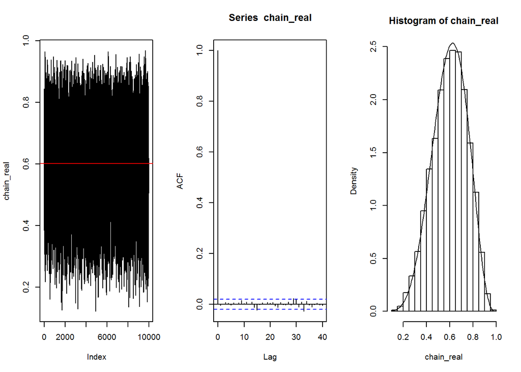

```r
chain_real <- c(10000,1)
for (i in 1:10000){
  chain_real[i]<- rbeta(1,6,4) #generation a real chain from beta (6,4)
}

par(mfrow=c(1,3))  #1 row, 3 columns
plot(chain_real,type = 'l');abline(h = mean(chain_real),col = 'red'); acf(chain_real); hist(chain_real,freq = FALSE)  #plot commands
curve(dbeta(x, 6, 4), add=TRUE)  #adding density function of beta(6,4) to histogram
```

```r
ks.test(chain, chain_real)
```

```
##
##  Two-sample Kolmogorov-Smirnov test
##
## data:  chain and chain_real
## D = 0.024222, p-value = 0.005661
## alternative hypothesis: two-sided
```

The figure is for the real distribution - namely the beta(6,4). The number given is for the Kolmogorov–Smirnov test. We can see the two sets of figure don’t really match with each other. The p value we get from the K-S test is quite small, which means the result is bad.

Then we try to use burn in and thining to improve the performance of the algorithm.We modify the code to the following.

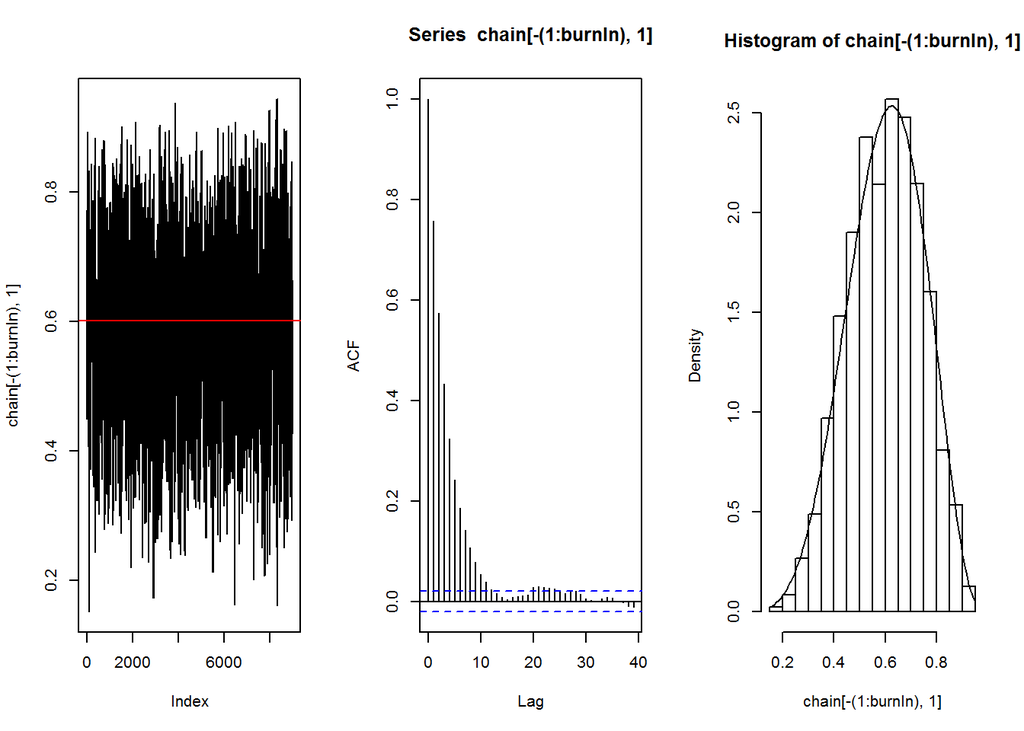

```r
#Defination of proposal function
proposalfunction <- function(c, phi_old){
  rbeta(1, c*phi_old,c*(1-phi_old))
}
#The constant in proposal function
c<-1
# MC algorithm
run_metropolis_MCMC <- function(c, iterations){
  chain = array(dim = c(iterations+1,1))
  chain[1,] = runif(1)
  for (i in 1:iterations){
    proposal = proposalfunction(c,chain[i,])
    probab = dbeta(proposal,6,4)/dbeta(chain[i,1],6,4)*dbeta(chain[i,],c*proposal,c*(1-proposal))/dbeta(proposal,c*chain[i,],c*(1-chain[i,])) # Acceptance Ratio, no min here.
    if (runif(1) < probab){
      chain[i+1,] = proposal
    }else{
      chain[i+1,] = chain[i,]
    }
  }
  return(chain)
}


chain=run_metropolis_MCMC(1, 10000)

burnIn = 1000

par(mfrow=c(1,3))  #1 row, 3 columns
plot(chain[-(1:burnIn),1],type = 'l');abline(h = mean(chain_real),col = 'red'); acf(chain[-(1:burnIn),1]);hist(chain[-(1:burnIn),1],freq = FALSE)  #plot commands
curve(dbeta(x, 6, 4), add=TRUE)  #adding density function of beta(6,4) to histogram
```

We can find that the probability density function is more close to the the real one.

## C=0.1

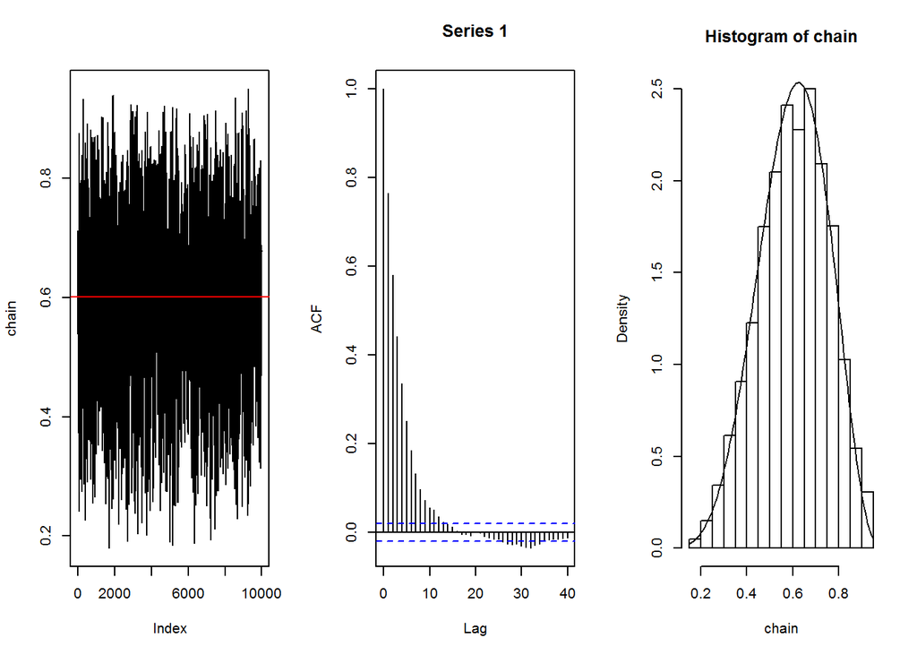

```r
#Defination of proposal function
proposalfunction <- function(c, phi_old){
  rbeta(1, c*phi_old,c*(1-phi_old))
}
#The constant in proposal function
c<-0.1
# MC algorithm
run_metropolis_MCMC <- function(c, iterations){
  chain = array(dim = c(iterations+1,1))
  chain[1,] = runif(1)
  for (i in 1:iterations){
    proposal = proposalfunction(c,chain[i,])

    probab = dbeta(proposal,6,4)/dbeta(chain[i,1],6,4)*dbeta(chain[i,],c*proposal,c*(1-proposal))/dbeta(proposal,c*chain[i,],c*(1-chain[i,])) # Acceptance Ratio
    if (runif(1) < probab){
      chain[i+1,] = proposal
    }else{
      chain[i+1,] = chain[i,]
    }
  }
  return(chain)
}

chain=run_metropolis_MCMC(1, 10000)

par(mfrow=c(1,3))  #1 row, 3 columns
plot(chain,type = 'l');abline(h = mean(chain_real),col = 'red'); acf(chain); hist(chain,freq = FALSE)  #plot commands
curve(dbeta(x, 6, 4), add=TRUE)  #adding density function of beta(6,4) to histogram
```

```r
ks.test(chain, chain_real)
```

```
##
##  Two-sample Kolmogorov-Smirnov test
##
## data:  chain and chain_real
## D = 0.024263, p-value = 0.005548
## alternative hypothesis: two-sided
```

## c=2.5

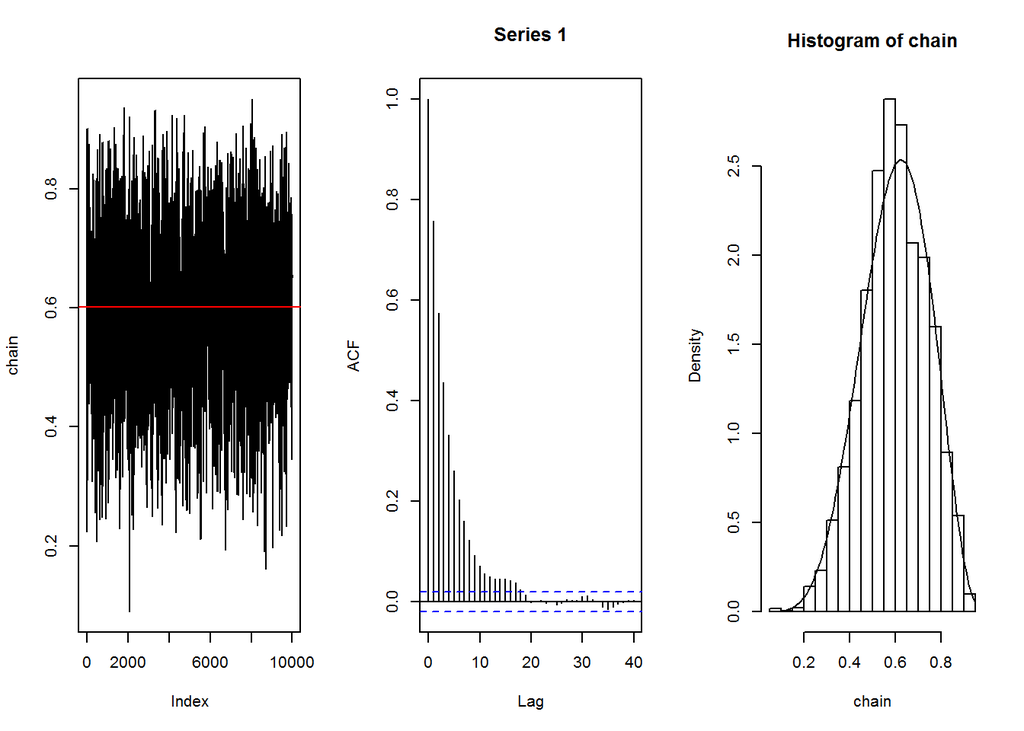

```r
#Defination of proposal function
proposalfunction <- function(c, phi_old){
  rbeta(1, c*phi_old,c*(1-phi_old))
}
#The constant in proposal function
c<-2.5
# MC algorithm
run_metropolis_MCMC <- function(c, iterations){
  chain = array(dim = c(iterations+1,1))
  chain[1,] = runif(1)
  for (i in 1:iterations){
    proposal = proposalfunction(c,chain[i,])

    probab = dbeta(proposal,6,4)/dbeta(chain[i,1],6,4)*dbeta(chain[i,],c*proposal,c*(1-proposal))/dbeta(proposal,c*chain[i,],c*(1-chain[i,])) # Acceptance Ratio
    if (runif(1) < probab){
      chain[i+1,] = proposal
    }else{
      chain[i+1,] = chain[i,]
    }
  }
  return(chain)
}

chain=run_metropolis_MCMC(1, 10000)

par(mfrow=c(1,3))  #1 row, 3 columns
plot(chain,type = 'l');abline(h = mean(chain_real),col = 'red'); acf(chain); hist(chain,freq = FALSE)  #plot commands
curve(dbeta(x, 6, 4), add=TRUE)  #adding density function of beta(6,4) to histogram
```

```r
ks.test(chain, chain_real)
```

```
##
##  Two-sample Kolmogorov-Smirnov test
##
## data:  chain and chain_real
## D = 0.04914, p-value = 6.509e-11
## alternative hypothesis: two-sided
```

## c=10

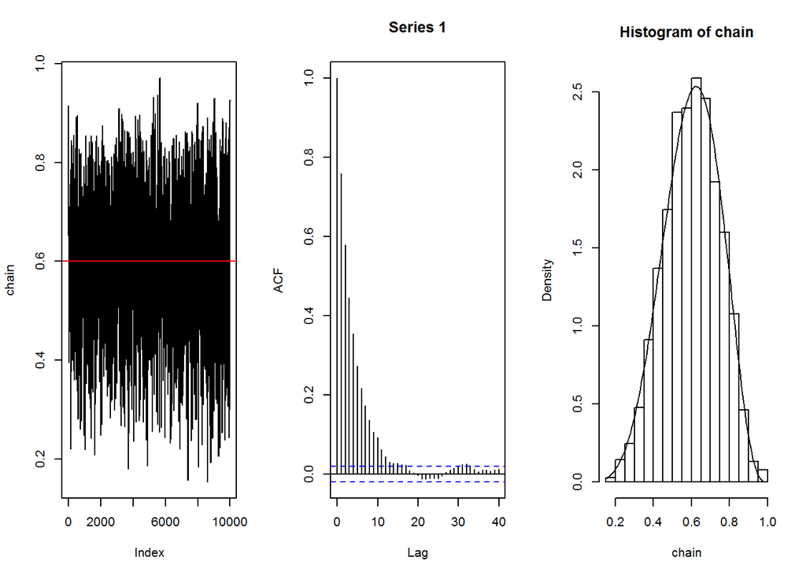

```r
#Defination of proposal function
proposalfunction <- function(c, phi_old){
  rbeta(1, c*phi_old,c*(1-phi_old))
}
#The constant in proposal function
c<-10
# MC algorithm
run_metropolis_MCMC <- function(c, iterations){
  chain = array(dim = c(iterations+1,1))
  chain[1,] = runif(1)
  for (i in 1:iterations){
    proposal = proposalfunction(c,chain[i,])

    probab = dbeta(proposal,6,4)/dbeta(chain[i,1],6,4)*dbeta(chain[i,],c*proposal,c*(1-proposal))/dbeta(proposal,c*chain[i,],c*(1-chain[i,])) # Acceptance Ratio
    if (runif(1) < probab){
      chain[i+1,] = proposal
    }else{
      chain[i+1,] = chain[i,]
    }
  }
  return(chain)
}

chain=run_metropolis_MCMC(1, 10000)

par(mfrow=c(1,3))  #1 row, 3 columns
plot(chain,type = 'l'); abline(h = mean(chain_real),col = 'red');acf(chain); hist(chain,freq = FALSE)  #plot commands
curve(dbeta(x, 6, 4), add=TRUE)  #adding density function of beta(6,4) to histogram
```

```r
ks.test(chain, chain_real)
```

```
##
##  Two-sample Kolmogorov-Smirnov test
##
## data:  chain and chain_real
## D = 0.019325, p-value = 0.04775
## alternative hypothesis: two-sided
```

## Gibbs sampling

We use inverse transform sampling here. 1. Generate our CDF
$$F_{X|Y}=\frac{1-e^{-yx}}{1-e^{-yB}}$$
$$F_{Y|X}=\frac{1-e^{-xy}}{1-e^{-xB}}$$
2. Generate two samples from the uniform distribution between 0 and 1. Name them P1 and P2. 3. For each value P1 and P2 in uniform sample, add new x and y.
$$x=-\frac{1}{y}log(1-p+pe^{-yB})$$
$$y=-\frac{1}{x}log(1-p+pe^{-xB})$$

## T=500

```
## The expectation of X
## 1.3134792796
```

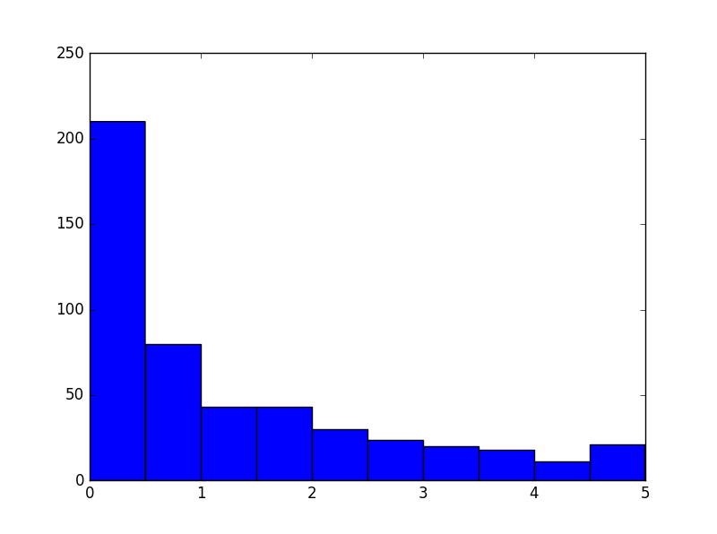

```python
from math import *
import random
import numpy
#import matplotlib.pyplot as plt
B = 5
T = 500
M = numpy.zeros((T, 3))


def gibbs(T,thin=10):
    x=1
    y=1
    #print "Iter  x  y"
    for i in range(T):
        for j in range(thin):
            p1= random.uniform(0,1)
            x=-1/y*log(1-p1+p1*exp(-y*B))
            p2= random.uniform(0,1)
            y=-1/x*log(1-p2+p2*exp(-x*B))
        M[i,0] = i
        M[i,1] = x
        M[i,2] = y
        #print i,x,y

gibbs(T)
#print M
print "The expectation of X"
print numpy.mean(M[:,1])
#print numpy.mean(M[:,2])
#plt.hist(M[:,1])
#plt.show()
```

## T=5000

```
## The expectation of X
## 1.2594661814
```

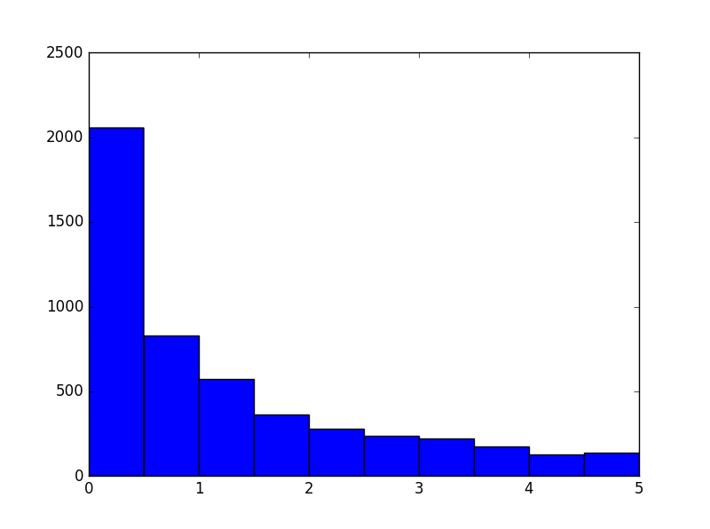

```python
from math import *
import random
import numpy
#import matplotlib.pyplot as plt
B = 5
T = 5000
M = numpy.zeros((T, 3))


def gibbs(T,thin=10):
    x=1
    y=1
    #print "Iter  x  y"
    for i in range(T):
        for j in range(thin):
            p1= random.uniform(0,1)
            x=-1/y*log(1-p1+p1*exp(-y*B))
            p2= random.uniform(0,1)
            y=-1/x*log(1-p2+p2*exp(-x*B))
        M[i,0] = i
        M[i,1] = x
        M[i,2] = y
        #print i,x,y

gibbs(T)
#print M
print "The expectation of X"
print numpy.mean(M[:,1])
#print numpy.mean(M[:,2])
#plt.hist(M[:,1])
#plt.show()
```

## T=50000

```
## The expectation of X
## 1.2657589482
```

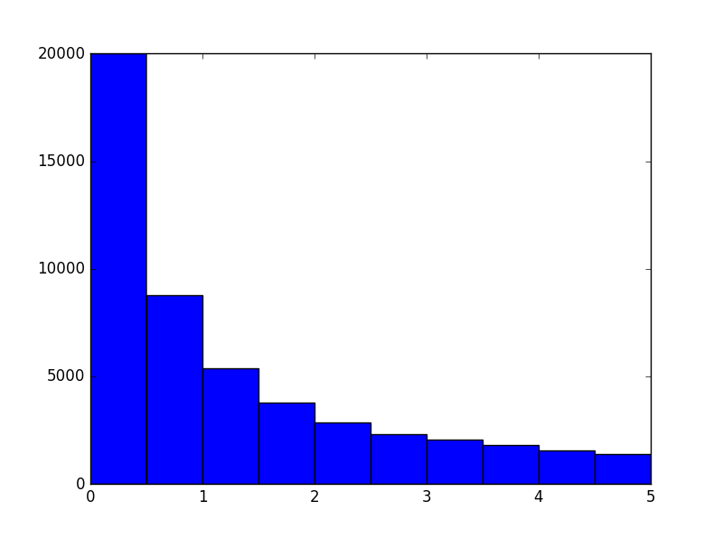

```python
from math import *
import random
import numpy
#import matplotlib.pyplot as plt
B = 5
T = 50000
M = numpy.zeros((T, 3))


def gibbs(T,thin=10):
    x=1
    y=1
    #print "Iter  x  y"
    for i in range(T):
        for j in range(thin):
            p1= random.uniform(0,1)
            x=-1/y*log(1-p1+p1*exp(-y*B))
            p2= random.uniform(0,1)
            y=-1/x*log(1-p2+p2*exp(-x*B))
        M[i,0] = i
        M[i,1] = x
        M[i,2] = y
        #print i,x,y

gibbs(T)
#print M
print "The expectation of X"
print numpy.mean(M[:,1])
#print numpy.mean(M[:,2])
#plt.hist(M[:,1])
#plt.show()
```